# ハロプログループの平均活動年数の推移をバーチャートレースで可視化

[@anemptyarchive](https://www.anarchive-beta.com/)

2022/06/01

# 平均活動年数の推移の可視化

ハロー！プロジェクトのグループ・ユニットの平均活動年数の推移をバーチャートレースで可視化します。

次のパッケージを利用します。

```r
# 利用パッケージ
library(tidyverse)
library(lubridate)
library(gganimate)
```

この記事では、基本的に`パッケージ名::関数名()`の記法を使うので、パッケージを読み込む必要はありません。  
ただし、パイプ演算子`%>%`を使うため`magrittr`と、作図コードがごちゃごちゃしないようにパッケージ名を省略するため`ggplot2`は読み込む必要があります。

## データの読込

「HP_DB」のデータを利用します。GitHub上のcsvデータをRから読み込めたらよかったのですがやり方が分からなかったので、ダウンロードしてローカルフォルダに保存しておきます。

保存先のフォルダパスを指定します。

```r
# フォルダパスを指定
dir_path <- "data/HP_DB-main/"
```

ファイルの読み込み時にファイル名を結合する(ファイルパスにする)ので、末尾を`/`にしておきます。

メンバーの情報を読み込みます。

```r
# メンバー一覧を読み込み
member_df <- readr::read_csv(
  file = paste0(dir_path, "member.csv"),
  col_types = readr::cols(
    memberID = "i",
    memberName = "c",
    HPjoinDate = readr::col_date(format = "%Y/%m/%d"),
    debutDate = readr::col_date(format = "%Y/%m/%d"),
    HPgradDate = readr::col_date(format = "%Y/%m/%d"),
    memberKana = "c",
    birthDate = readr::col_date(format = "%Y/%m/%d")
  )
) %>%
  dplyr::arrange(memberID) # 昇順に並べ替え
member_df
```

```
## # A tibble: 273 x 7
##    memberID memberName HPjoinDate debutDate  HPgradDate memberKana    birthDate
##       <int> <chr>      <date>     <date>     <date>     <chr>         <date>
##  1        1 中澤裕子   1997-09-14 1998-01-28 2009-03-31 なかざわゆう~ 1973-06-19
##  2        2 石黒彩     1997-09-14 1998-01-28 2000-01-07 いしぐろあや  1978-05-12
##  3        3 飯田圭織   1997-09-14 1998-01-28 2009-03-31 いいだかおり  1981-08-08
##  4        4 安倍なつみ 1997-09-14 1998-01-28 2009-03-31 あべなつみ    1981-08-10
##  5        5 福田明日香 1997-09-14 1998-01-28 1999-04-18 ふくだあすか  1984-12-17
##  6        6 平家みちよ 1997-11-05 1997-11-05 2002-11-07 へいけみちよ  1979-04-06
##  7        7 保田圭     1998-05-03 1998-05-03 2009-03-31 やすだけい    1980-12-06
##  8        8 矢口真里   1998-05-03 1998-05-03 2005-04-14 やぐちまり    1983-01-20
##  9        9 市井紗耶香 1998-05-03 1998-05-03 2000-05-21 いちいさやか  1983-12-31
## 10       10 信田美帆   1999-02-21 1999-04-21 2000-10-09 しのだみほ    1972-05-18
## # ... with 263 more rows
```

```r
# 重複データを確認
member_df %>%
  dplyr::filter(memberID %in% c(19, 41))
```

```
## # A tibble: 4 x 7
##   memberID memberName HPjoinDate debutDate  HPgradDate memberKana   birthDate
##      <int> <chr>      <date>     <date>     <date>     <chr>        <date>
## 1       19 戸田鈴音   1999-04-27 NA         2000-04-30 とだりんね   1981-02-06
## 2       19 りんね     2000-05-01 2001-04-18 2002-10-13 りんね       1981-02-06
## 3       41 紺野あさ美 2001-08-26 2001-08-26 2006-07-23 こんのあさみ 1987-05-07
## 4       41 紺野あさ美 2007-07-15 2007-07-15 2009-03-31 こんのあさみ 1987-05-07
```

「戸田鈴音」さんは改名によるもので、「紺野あさ美」さんはモーニング娘。卒業の後にハロプロ復帰したためです。

グループの情報を読み込みます。

```r
# グループ一覧を読み込み
group_df <- readr::read_csv(
  file = paste0(dir_path, "group.csv"),
  col_types = readr::cols(
    groupID = "i",
    groupName = "c",
    formDate = readr::col_date(format = "%Y/%m/%d"),
    dissolveDate = readr::col_date(format = "%Y/%m/%d"),
    isUnit = "l"
  )
) %>%
  dplyr::arrange(groupID, formDate) # 昇順に並べ替え
group_df
```

```
## # A tibble: 60 x 5
##    groupID groupName          formDate   dissolveDate isUnit
##      <int> <chr>              <date>     <date>       <lgl>
##  1       1 モーニング娘。     1997-09-14 2013-12-31   FALSE
##  2       1 モーニング娘。 '14 2014-01-01 2014-12-31   FALSE
##  3       1 モーニング娘。 '15 2015-01-01 2015-12-31   FALSE
##  4       1 モーニング娘。 '16 2016-01-01 2016-12-31   FALSE
##  5       1 モーニング娘。 '17 2017-01-01 2017-12-31   FALSE
##  6       1 モーニング娘。 '18 2018-01-01 2018-12-31   FALSE
##  7       1 モーニング娘。 '19 2019-01-01 2019-12-31   FALSE
##  8       1 モーニング娘。 '20 2020-01-01 2020-12-31   FALSE
##  9       1 モーニング娘。 '21 2021-01-01 2021-12-31   FALSE
## 10       1 モーニング娘。 '22 2022-01-01 NA           FALSE
## # ... with 50 more rows
```

group.csvは、グループID・グループ名・結成日・解散日・ユニットかどうかの5列のcsvファイルです。改名グループであれば結成日・解散日は改名日を表し、現在活動中であれば解散日が欠損値になります。  
例えば、「モーニング娘。とモーニング娘。’14」「スマイレージとアンジュルム」「カントリー娘。とカントリー・ガールズ」は同一のグループとして共通のグループIDを持ちます。よって、`groupID`列の値は重複し、`groupName`列の値(文字列)は重複しません。

メンバーの加入日・卒業日の情報を読み込みます。

```r
# 加入・卒業日一覧を読み込み
join_df <- readr::read_csv(
  file = paste0(dir_path, "join.csv"),
  col_types = readr::cols(
    memberID = "i",
    groupID = "i",
    joinDate = readr::col_date(format = "%Y/%m/%d"),
    gradDate = readr::col_date(format = "%Y/%m/%d")
  )
) %>%
  dplyr::arrange(joinDate, memberID, groupID) # 昇順に並べ替え
join_df
```

```
## # A tibble: 514 x 4
##    memberID groupID joinDate   gradDate
##       <int>   <int> <date>     <date>
##  1        1       1 1997-09-14 2001-04-15
##  2        2       1 1997-09-14 2000-01-07
##  3        3       1 1997-09-14 2005-01-30
##  4        4       1 1997-09-14 2004-01-25
##  5        5       1 1997-09-14 1999-04-18
##  6        7       1 1998-05-03 2003-05-05
##  7        8       1 1998-05-03 2005-04-14
##  8        9       1 1998-05-03 2000-05-21
##  9        2       2 1998-10-18 2000-01-07
## 10        3       2 1998-10-18 2002-09-23
## # ... with 504 more rows
```

join.csvは、メンバーID・グループID・加入日・卒業日の4列のcsvファイルです。現在活動中であれば卒業日が欠損値になります。  
member.cscのメンバーID、group.csvのグループIDと対応しています。

## 期間の指定

```r
# 期間を指定
date_from <- "1997-09-01"
date_to   <- "2022-05-31"
#date_to   <- lubridate::today()
```

開始日を`date_from`、終了日を`date_to`として期間を指定します。文字列で`yyyy-mm-dd`や`yyyy/mm/dd`、`yyyymmdd`などと指定できます。現在の日付を使う場合は、`today()`で設定します。

集計に利用する期間内の全ての月を持つベクトルを作成します。

```r
# 月ベクトルを作成
date_vec <- seq(
  from = date_from %>%
    lubridate::as_date() %>%
    lubridate::floor_date(unit = "mon"),
  to = date_to %>%
    lubridate::as_date() %>%
    lubridate::floor_date(unit = "mon"),
  by = "mon"
)
length(date_vec) # フレーム数
```

```
## [1] 297
```

`seq()`で、第1引数`from`から第2引数`to`までのベクトルを作成します。第3引数`by`に`"mon"`を指定すると、1か月間隔のベクトルを作成します。  
文字列型で指定した開始日を、`as_date()`でDate型に変換し、さらに`floor_date()`の`unit`引数に`"mon"`を指定して月初の日付にして(日にちを切り捨てて)使います。

アニメーションでは、1月ずつフレーム(グラフ)を切り替えるので、`date_vec`の要素数がフレーム数になります。

## 平均活動年数の集計と順位付け

平均活動年数を集計してランキングを付けます。

受け皿となるデータフレームの作成用にサイズを取得します。

```r
# サイズを取得
date_size   <- length(date_vec)
group_size  <- max(group_df[["groupID"]])
member_size <- max(member_df[["memberID"]])
```

集計した期間の月数・グループ数・メンバー数を取得します。

各月における「平均活動年数」と「順位」のデータフレームを作成します。

```r
# 平均活動年数を集計
rank_df <- tibble::tibble(
  date = rep(date_vec, each = group_size*member_size),
  groupID = rep(rep(1:group_size, times = date_size), each = member_size),
  memberID = rep(1:member_size, times = date_size*group_size)
) %>% # 全ての組み合わせを作成
  dplyr::left_join(group_name_df, by = c("date", "groupID")) %>% # グループ情報を結合
  dplyr::filter(date >= formDate, date <= dissolveDate) %>% # 活動中のグループを抽出
  dplyr::select(!c(formDate, dissolveDate)) %>% # 不要な列を削除
  dplyr::left_join(
    join_df %>%
      dplyr::mutate(
        joinDate = lubridate::floor_date(joinDate, unit = "mon"),
        gradDate = lubridate::floor_date(gradDate, unit = "mon")
      ), # 月単位に切り捨て
    by = c("groupID", "memberID")
  ) %>% # 加入メンバー情報を結合
  dplyr::filter(date >= joinDate, date < gradDate | is.na(gradDate)) %>% # グループ活動中のメンバーを抽出
  dplyr::select(!c(joinDate, gradDate)) %>% # 不要な列を削除
  dplyr::left_join(
    member_df %>%
      dplyr::distinct(memberID, .keep_all = TRUE) %>% # 重複を除去
      dplyr::mutate(HPjoinDate = lubridate::floor_date(HPjoinDate, unit  = "mon")), # 月単位に切り捨て
    by = "memberID"
  ) %>% # メンバー情報を結合
  dplyr::select(date, groupID, groupName, memberID, memberName, HPjoinDate) %>% # 利用する列を選択
  dplyr::mutate(
    moonage = lubridate::interval(start = HPjoinDate, end = date) %>%
      lubridate::time_length(unit = "mon")
  ) %>% # メンバーの活動月数を計算
  dplyr::group_by(date, groupID, groupName) %>% # 平均活動月数の計算用にグループ化
  dplyr::summarise(
    moonage = sum(moonage),
    member_n = dplyr::n(),
    .groups = "drop"
  ) %>% # グループの総活動月数と(計算に使った)メンバー数を計算
  dplyr::mutate(average_moonage = moonage / member_n) %>% # グループの平均活動月数を計算
  dplyr::bind_rows(member_0_df) %>% # 結成前月・解散月を追加
  dplyr::arrange(date, average_moonage, groupID) %>% # ランク付け用に並べ替え
  dplyr::group_by(date) %>% # ランク付け用にグループ化
  dplyr::mutate(
    groupID = factor(groupID),
    year = average_moonage %/% 12,
    month = round(average_moonage %% 12, digits = 1),
    ranking = dplyr::row_number(-average_moonage),
  ) %>% # ランク付けとラベル用の値を追加
  dplyr::ungroup() %>% # グループ化の解除
  dplyr::select(date, groupID, groupName, average_moonage, year, month, ranking) %>% # 利用する列を選択
  dplyr::arrange(date, ranking) # 昇順に並べ替え
rank_df
```

```
## # A tibble: 3,209 x 7
##    date       groupID groupName      average_moonage  year month ranking
##    <date>     <fct>   <chr>                    <dbl> <dbl> <dbl>   <int>
##  1 1997-09-01 1       モーニング娘。               0     0     0       1
##  2 1997-10-01 1       モーニング娘。               1     0     1       1
##  3 1997-11-01 1       モーニング娘。               2     0     2       1
##  4 1997-12-01 1       モーニング娘。               3     0     3       1
##  5 1998-01-01 1       モーニング娘。               4     0     4       1
##  6 1998-02-01 1       モーニング娘。               5     0     5       1
##  7 1998-03-01 1       モーニング娘。               6     0     6       1
##  8 1998-04-01 1       モーニング娘。               7     0     7       1
##  9 1998-05-01 1       モーニング娘。               5     0     5       1
## 10 1998-06-01 1       モーニング娘。               6     0     6       1
## # ... with 3,199 more rows
```

まずは、データの受け皿となる、月・グループID・メンバーIDの全ての組み合わせを持つデータフレームを作成します。  
次に、各グループの(改名に対応した)名前と、各メンバーの加入・卒業日の情報を結合して、不要な行(組み合わせ)を削除します。  
続いて、各メンバーのハロプロ加入日の情報を結合して、各メンバーの活動月数を計算し、各グループの平均活動月数を計算します。  
最後に、各グループの平均活動月数に応じて順位付けして、作図用にデータを編集します。

各処理を細かく見ます。

**・コード(クリックで展開)**

月・グループID・メンバーIDの全ての組み合わせを持つデータフレームを作成します。

```r
# 受け皿を作成
df1 <- tibble::tibble(
  date = rep(date_vec, each = group_size*member_size),
  groupID = rep(rep(1:group_size, times = date_size), each = member_size),
  memberID = rep(1:member_size, times = date_size*group_size)
) # 全ての組み合わせを作成
df1
```

```
## # A tibble: 3,528,360 x 3
##    date       groupID memberID
##    <date>       <int>    <int>
##  1 1997-09-01       1        1
##  2 1997-09-01       1        2
##  3 1997-09-01       1        3
##  4 1997-09-01       1        4
##  5 1997-09-01       1        5
##  6 1997-09-01       1        6
##  7 1997-09-01       1        7
##  8 1997-09-01       1        8
##  9 1997-09-01       1        9
## 10 1997-09-01       1       10
## # ... with 3,528,350 more rows
```

```r
tibble::tibble(
  x = rep(1:3, each = 3*3),
  y = rep(rep(1:3, times = 3), each = 3),
  z = rep(1:3, times = 3*3)
)
```

```
## # A tibble: 27 x 3
##        x     y     z
##    <int> <int> <int>
##  1     1     1     1
##  2     1     1     2
##  3     1     1     3
##  4     1     2     1
##  5     1     2     2
##  6     1     2     3
##  7     1     3     1
##  8     1     3     2
##  9     1     3     3
## 10     2     1     1
## # ... with 17 more rows
```

各グループの各月に対応した名前・結成日・解散日の情報を結合します。

```r
# グループの情報を結合
df2 <- df1 %>%
  dplyr::left_join(group_name_df, by = c("date", "groupID")) %>% # グループ情報を結合
  dplyr::filter(date >= formDate, date <= dissolveDate) # 活動中のグループを抽出
df2
```

```
## # A tibble: 874,800 x 6
##    date       groupID memberID groupName      formDate   dissolveDate
##    <date>       <int>    <int> <chr>          <date>     <date>
##  1 1997-09-01       1        1 モーニング娘。 1997-09-01 2013-12-01
##  2 1997-09-01       1        2 モーニング娘。 1997-09-01 2013-12-01
##  3 1997-09-01       1        3 モーニング娘。 1997-09-01 2013-12-01
##  4 1997-09-01       1        4 モーニング娘。 1997-09-01 2013-12-01
##  5 1997-09-01       1        5 モーニング娘。 1997-09-01 2013-12-01
##  6 1997-09-01       1        6 モーニング娘。 1997-09-01 2013-12-01
##  7 1997-09-01       1        7 モーニング娘。 1997-09-01 2013-12-01
##  8 1997-09-01       1        8 モーニング娘。 1997-09-01 2013-12-01
##  9 1997-09-01       1        9 モーニング娘。 1997-09-01 2013-12-01
## 10 1997-09-01       1       10 モーニング娘。 1997-09-01 2013-12-01
## # ... with 874,790 more rows
```

`left_join()`で、`group_name_df`からグループ名(`groupName`列)・結成月(`formDate`列)・解散月(`dissolveDate`列)の情報を、月(`date`列)とグループ(`groupID`列)で対応付けて結合します。  
`date`が`formDate`以上で`dissoveDate`以下の行を抽出します。各月において活動中のグループが得られ(`groupID`について不要なデータが削除され)ます。

各メンバーのグループ加入・卒業日の情報を結合します。

```r
# 加入・卒業の情報を結合
df3 <- df2 %>%
  dplyr::select(!c(formDate, dissolveDate)) %>% # 不要な列を削除
  dplyr::left_join(
    join_df %>%
      dplyr::mutate(
        joinDate = lubridate::floor_date(joinDate, unit = "mon"),
        gradDate = lubridate::floor_date(gradDate, unit = "mon")
      ), # 月単位に切り捨て
    by = c("groupID", "memberID")
  ) %>% # 加入メンバー情報を結合
  dplyr::filter(date >= joinDate, date < gradDate | is.na(gradDate)) # グループ活動中のメンバーを抽出
df3
```

```
## # A tibble: 21,189 x 6
##    date       groupID memberID groupName      joinDate   gradDate
##    <date>       <int>    <int> <chr>          <date>     <date>
##  1 1997-09-01       1        1 モーニング娘。 1997-09-01 2001-04-01
##  2 1997-09-01       1        2 モーニング娘。 1997-09-01 2000-01-01
##  3 1997-09-01       1        3 モーニング娘。 1997-09-01 2005-01-01
##  4 1997-09-01       1        4 モーニング娘。 1997-09-01 2004-01-01
##  5 1997-09-01       1        5 モーニング娘。 1997-09-01 1999-04-01
##  6 1997-10-01       1        1 モーニング娘。 1997-09-01 2001-04-01
##  7 1997-10-01       1        2 モーニング娘。 1997-09-01 2000-01-01
##  8 1997-10-01       1        3 モーニング娘。 1997-09-01 2005-01-01
##  9 1997-10-01       1        4 モーニング娘。 1997-09-01 2004-01-01
## 10 1997-10-01       1        5 モーニング娘。 1997-09-01 1999-04-01
## # ... with 21,179 more rows
```

各メンバーの加入日の情報を結合して、活動月数を計算します。

```r
# 活動月数を計算
df4 <- df3 %>%
  dplyr::select(!c(joinDate, gradDate)) %>% # 不要な列を削除
  dplyr::left_join(
    member_df %>%
      dplyr::distinct(memberID, .keep_all = TRUE) %>% # 重複を除去
      dplyr::mutate(HPjoinDate = lubridate::floor_date(HPjoinDate, unit  = "mon")), # 月単位に切り捨て
    by = "memberID"
  ) %>% # メンバー情報を結合
  dplyr::select(date, groupID, groupName, memberID, memberName, HPjoinDate) %>% # 利用する列を選択
  dplyr::mutate(
    moonage = lubridate::interval(start = HPjoinDate, end = date) %>%
      lubridate::time_length(unit = "mon")
  ) # メンバーの活動月数を計算
df4
```

```
## # A tibble: 21,189 x 7
##    date       groupID groupName      memberID memberName HPjoinDate moonage
##    <date>       <int> <chr>             <int> <chr>      <date>       <dbl>
##  1 1997-09-01       1 モーニング娘。        1 中澤裕子   1997-09-01       0
##  2 1997-09-01       1 モーニング娘。        2 石黒彩     1997-09-01       0
##  3 1997-09-01       1 モーニング娘。        3 飯田圭織   1997-09-01       0
##  4 1997-09-01       1 モーニング娘。        4 安倍なつみ 1997-09-01       0
##  5 1997-09-01       1 モーニング娘。        5 福田明日香 1997-09-01       0
##  6 1997-10-01       1 モーニング娘。        1 中澤裕子   1997-09-01       1
##  7 1997-10-01       1 モーニング娘。        2 石黒彩     1997-09-01       1
##  8 1997-10-01       1 モーニング娘。        3 飯田圭織   1997-09-01       1
##  9 1997-10-01       1 モーニング娘。        4 安倍なつみ 1997-09-01       1
## 10 1997-10-01       1 モーニング娘。        5 福田明日香 1997-09-01       1
## # ... with 21,179 more rows
```

`left_join()`で、`member_df`から加入日(`HPjoinDate`列)の情報を、メンバー(`memberID`列)で対応付けて結合します。メンバー名(`memberName`列)は確認用です。結合時に、`distinct()`で重複データを削除し、加入日を加入月に変換します。  
`interval()`と`time_length()`で、`HPjoinDate`から`date`までの月数を求めます。各月におけるメンバーの活動月数が得られます。

各グループの平均活動月数を計算します。

```r
# 平均月齢を計算
df5 <- df4 %>%
  dplyr::group_by(date, groupID, groupName) %>% # 平均活動月数の計算用にグループ化
  dplyr::summarise(
    moonage = sum(moonage),
    member_n = dplyr::n(),
    .groups = "drop"
  ) %>% # グループの総活動月数と(計算に使った)メンバー数を計算
  dplyr::mutate(average_moonage = moonage / member_n) # グループの平均活動月数を計算
df5
```

```
## # A tibble: 3,133 x 6
##    date       groupID groupName      moonage member_n average_moonage
##    <date>       <int> <chr>            <dbl>    <int>           <dbl>
##  1 1997-09-01       1 モーニング娘。       0        5               0
##  2 1997-10-01       1 モーニング娘。       5        5               1
##  3 1997-11-01       1 モーニング娘。      10        5               2
##  4 1997-12-01       1 モーニング娘。      15        5               3
##  5 1998-01-01       1 モーニング娘。      20        5               4
##  6 1998-02-01       1 モーニング娘。      25        5               5
##  7 1998-03-01       1 モーニング娘。      30        5               6
##  8 1998-04-01       1 モーニング娘。      35        5               7
##  9 1998-05-01       1 モーニング娘。      40        8               5
## 10 1998-06-01       1 モーニング娘。      48        8               6
## # ... with 3,123 more rows
```

各メンバーの活動月数を`summarise()`で合計します。また、メンバー数を`n()`でカウントします。  
合計活動月数(`moonage`列)をメンバー数(`member_n`列)で割って、平均活動月数(`average_moonage`列)とします。

作図用に編集します。

```r
# 作図用に編集
df6 <- df5 %>%
  dplyr::bind_rows(member_0_df) %>% # 結成前月・解散月を追加
  dplyr::arrange(date, average_moonage, groupID) %>% # ランク付け用に並べ替え
  dplyr::group_by(date) %>% # ランク付け用にグループ化
  dplyr::mutate(
    groupID = factor(groupID),
    year = average_moonage %/% 12,
    month = round(average_moonage %% 12, digits = 1),
    ranking = dplyr::row_number(-average_moonage),
  ) %>% # ランク付けとラベル用の値を追加
  dplyr::ungroup() %>% # グループ化の解除
  #dplyr::select(date, groupID, groupName, average_moonage, year, month, ranking) %>% # 利用する列を選択
  dplyr::arrange(date, ranking) # 昇順に並べ替え
df6
```

```
## # A tibble: 3,209 x 9
##    date       groupID groupName     moonage member_n average_moonage  year month
##    <date>     <fct>   <chr>           <dbl>    <dbl>           <dbl> <dbl> <dbl>
##  1 1997-09-01 1       モーニング娘~       0        5               0     0     0
##  2 1997-10-01 1       モーニング娘~       5        5               1     0     1
##  3 1997-11-01 1       モーニング娘~      10        5               2     0     2
##  4 1997-12-01 1       モーニング娘~      15        5               3     0     3
##  5 1998-01-01 1       モーニング娘~      20        5               4     0     4
##  6 1998-02-01 1       モーニング娘~      25        5               5     0     5
##  7 1998-03-01 1       モーニング娘~      30        5               6     0     6
##  8 1998-04-01 1       モーニング娘~      35        5               7     0     7
##  9 1998-05-01 1       モーニング娘~      40        8               5     0     5
## 10 1998-06-01 1       モーニング娘~      48        8               6     0     6
## # ... with 3,199 more rows, and 1 more variable: ranking <int>
```

以上で、必要なデータを得られました。次は、作図を行います。

## 推移の可視化

平均活動年数と順位を棒グラフで可視化します。

### バーチャートレースの作成

平均活動年数の推移をバーチャートレースで可視化します。バーチャートレースの作図については別資料を参照してください。

フレームに関する値を指定します。

```r
# 遷移フレーム数を指定
t <- 8

# 一時停止フレーム数を指定
s <- 2

# 1秒間に表示する月数を指定:(値が大きいと意図した通りにならない)
mps <- 3

# フレーム数を取得
n <- length(unique(rank_df[["date"]]))
n
```

```
## [1] 297
```

現月と次月のグラフを繋ぐアニメーションのフレーム数を`t`として、整数を指定します。  
各月のグラフで一時停止するフレーム数を`s`として、整数を指定します。  
基本となるフレーム数(月の数)を`n`とします。

バーチャートレースを作成します。

```r
# バーチャートレースを作成:(y軸可変)
anim <- ggplot(rank_df, aes(x = ranking, y = average_moonage, fill = groupID, color = groupID)) +
  geom_bar(stat = "identity", width = 0.9, alpha = 0.8) + # 平均活動月数バー
  geom_text(aes(y = 0, label = paste(groupName, " ")), hjust = 1) + # グループ名ラベル
  geom_text(aes(label = paste(" ", year, "年", month, "か月")), hjust = 0) + # 平均活動年数ラベル
  gganimate::transition_states(states = date, transition_length = t, state_length = s, wrap = FALSE) + # フレーム
  gganimate::ease_aes("cubic-in-out") + # アニメーションの緩急
  gganimate::view_follow(fixed_x = TRUE) + # 表示範囲のフィット
  coord_flip(clip = "off", expand = FALSE) + # 軸の入れ変え
  scale_x_reverse() + # x軸を反転
  theme(
    axis.title.x = element_blank(), # x軸のラベル
    axis.title.y = element_blank(), # y軸のラベル
    axis.text.x = element_blank(), # x軸の目盛ラベル
    axis.text.y = element_blank(), # y軸の目盛ラベル
    axis.ticks.x = element_blank(), # x軸の目盛指示線
    axis.ticks.y = element_blank(), # y軸の目盛指示線
    #panel.grid.major.x = element_line(color = "grey", size = 0.1), # x軸の主目盛線
    panel.grid.major.y = element_blank(), # y軸の主目盛線
    #panel.grid.minor.x = element_line(color = "grey", size = 0.1), # x軸の補助目盛線
    panel.grid.minor.y = element_blank(), # y軸の補助目盛線
    panel.border = element_blank(), # グラフ領域の枠線
    #panel.background = element_blank(), # グラフ領域の背景
    plot.title = element_text(color = "black", face = "bold", size = 20, hjust = 0.5), # 全体のタイトル
    plot.subtitle = element_text(color = "black", size = 15, hjust = 0.5), # 全体のサブタイトル
    plot.margin = margin(t = 10, r = 100, b = 10, l = 150, unit = "pt"), # 全体の余白
    legend.position = "none" # 凡例の表示位置
  ) + # 図の体裁
  labs(
    title = "ハロプログループの平均活動年数の推移",
    subtitle = "{lubridate::year(closest_state)}年{lubridate::month(closest_state)}月",
    caption = "データ:「https://github.com/xxgentaroxx/HP_DB」"
  ) # ラベル
```

`animate()`でgif画像を作成します。

```r
# gif画像を作成
g <- gganimate::animate(
  plot = anim,
  nframes = n*(t+s), fps = (t+s)*mps,
  width = 900, height = 800
)
g
```

[output not shown]

`plot`引数にグラフ、`nframes`引数にフレーム数、`fps`引数に1秒当たりのフレーム数を指定します。

`anim_save()`でgif画像を保存します。

```r
# gif画像を保存
gganimate::anim_save(filename = "output/AverageExperience.gif", animation = g)
```

`filename`引数にファイルパス(`"(保存する)フォルダ名/(作成する)ファイル名.gif"`)、`animation`引数に作成したgif画像を指定します。

動画を作成する場合は、`renderer`引数を指定します。

```r
# 動画を作成と保存
m <- gganimate::animate(
  plot = anim,
  nframes = n*(t+s), fps = (t+s)*mps,
  width = 900, height = 800,
  renderer = gganimate::av_renderer(file = "output/AverageExperience.mp4")
)
```

`renderer`引数に、レンダリング方法に応じた関数を指定します。この例では、`av_renderer()`を使います。  
`av_renderer()`の`file`引数に保存先のファイルパス(`"(保存する)フォルダ名/(作成する)ファイル名.mp4"`)を指定します。

### 月を指定して作図

最後に、指定した月における平均年数のグラフを作成します。

月を指定して、作図用のデータを作成します。

```r
# 月を指定
date_val <- "2022-05-01"

# 作図用のデータを抽出
tmp_rank_df <- rank_df %>%
  dplyr::filter(date == lubridate::as_date(date_val))

# 平均活動年数の最大値を取得
y_max <- max(tmp_rank_df[["average_moonage"]]) %/% 12
y_max
```

```
## [1] 8
```

y軸目盛の編集用に、平均活動年数の最大値`y_max`を作成しておきます。

棒グラフを作成します。

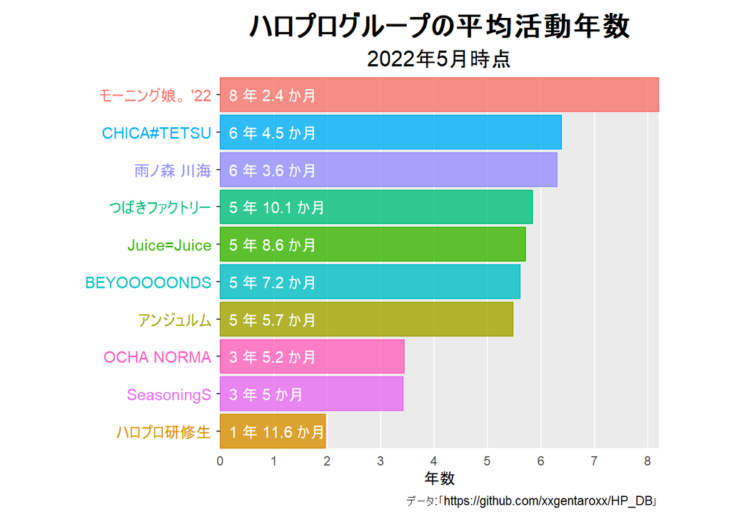

```r
# 棒グラフを作成
graph <- ggplot(tmp_rank_df, aes(x = ranking, y = average_moonage, fill = groupID, color = groupID)) +
  geom_bar(stat = "identity", width = 0.9, alpha = 0.8) + # 平均活動月数バー
  geom_text(aes(y = 0, label = paste(groupName, " ")), hjust = 1) + # グループ名ラベル
  geom_text(aes(y = 0, label = paste(" ", year, "年", month, "か月")), hjust = 0, color = "white") + # 平均活動年数ラベル
  coord_flip(clip = "off", expand = FALSE) + # 軸の入れ変え
  scale_x_reverse(breaks = 1:nrow(tmp_rank_df)) + # x軸(縦軸)を反転
  scale_y_continuous(breaks = 0:y_max*12, labels = 0:y_max) + # y軸(横軸)のラベル
  theme(
    axis.title.y = element_blank(), # y軸のラベル
    axis.text.y = element_blank(), # y軸の目盛ラベル
    axis.ticks.x = element_blank(), # x軸の目盛指示線
    #panel.grid.major.x = element_line(color = "grey", size = 0.1), # x軸の主目盛線
    panel.grid.major.y = element_blank(), # y軸の主目盛線
    panel.grid.minor.x = element_blank(), # x軸の補助目盛線
    panel.grid.minor.y = element_blank(), # y軸の補助目盛線
    panel.border = element_blank(), # グラフ領域の枠線
    #panel.background = element_blank(), # グラフ領域の背景
    plot.title = element_text(color = "black", face = "bold", size = 20, hjust = 0.5), # 全体のタイトル
    plot.subtitle = element_text(color = "black", size = 15, hjust = 0.5), # 全体のサブタイトル
    plot.margin = margin(t = 10, r = 50, b = 10, l = 150, unit = "pt"), # 全体の余白
    legend.position = "none" # 凡例の表示位置
  ) + # 図の体裁
  labs(
    title = "ハロプログループの平均活動年数",
    subtitle = paste0(lubridate::year(date_val), "年", lubridate::month(date_val), "月時点"),
    y = "年数",
    caption = "データ:「https://github.com/xxgentaroxx/HP_DB」"
  ) # ラベル
graph
```

y軸(横軸)の値は、データ上では活動月数です。これを年数に対応させて表示します。`scale_y_continuous()`の`breaks`引数に目盛位置、`labels`引数に目盛ラベルを指定します。年数を使って目盛位置を指定するには、値を12倍して月数に変換する必要があります。

`ggsave()`で画像を保存できます。

```r
# 画像を保存
ggplot2::ggsave(
  filename = paste0("output/AverageExperience_", date_val, ".png"), plot = graph,
  width = 24, height = 18, units = "cm", dpi = 100
)
```

以上で、平均活動年数の推移を可視化できました。